# Predict Bike Sharing Demand with AutoGluon Template

## Project: Predict Bike Sharing Demand with AutoGluon

This notebook is a template with each step that you need to complete for the project.

Please fill in your code where there are explicit `?` markers in the notebook. You are welcome to add more cells and code as you see fit.

Once you have completed all the code implementations, please export your notebook as a HTML file so the reviews can view your code. Make sure you have all outputs correctly outputted.

`File-> Export Notebook As... -> Export Notebook as HTML`

There is a writeup to complete as well after all code implememtation is done. Please answer all questions and attach the necessary tables and charts. You can complete the writeup in either markdown or PDF.

Completing the code template and writeup template will cover all of the rubric points for this project.

The rubric contains "Stand Out Suggestions" for enhancing the project beyond the minimum requirements. The stand out suggestions are optional. If you decide to pursue the "stand out suggestions", you can include the code in this notebook and also discuss the results in the writeup file.

## Step 1: Create an account with Kaggle

### Create Kaggle Account and download API key

Below is example of steps to get the API username and key. Each student will have their own username and key.

1. Open account settings.

2. Scroll down to API and click Create New API Token.

3. Open up `kaggle.json` and use the username and key.


## Step 2: Download the Kaggle dataset using the kaggle python library

### Open up Sagemaker Studio and use starter template

1. Notebook should be using a `ml.t3.medium` instance (2 vCPU + 4 GiB)
2. Notebook should be using kernal: `Python 3 (MXNet 1.8 Python 3.7 CPU Optimized)`

### Install packages

```python
# !pip install -U pip
# !pip install -U setuptools wheel
# !pip install -U "mxnet<2.0.0" bokeh==2.0.1
# !pip install autogluon --no-cache-dir
# # Without --no-cache-dir, smaller aws instances may have trouble installing
```

### Setup Kaggle API Key

```python
# create the .kaggle directory and an empty kaggle.json file
!mkdir -p /root/.kaggle
!touch /root/.kaggle/kaggle.json
!chmod 600 /root/.kaggle/kaggle.json
```

```python
# Fill in your user name and key from creating the kaggle account and API token file
import json
kaggle_username = "muthoninduhiu"
kaggle_key = "368f1139ed744db27694752baab07c60"

# Save API token the kaggle.json file
with open("/root/.kaggle/kaggle.json", "w") as f:
    f.write(json.dumps({"username": kaggle_username, "key": kaggle_key}))
```

### Download and explore dataset

### Go to the bike sharing demand competition and agree to the terms

```python
# Download the dataset, it will be in a .zip file so you'll need to unzip it as well.
!kaggle competitions download -c bike-sharing-demand
# If you already downloaded it you can use the -o command to overwrite the file
!unzip -o bike-sharing-demand.zip
```

```
Downloading bike-sharing-demand.zip to /root/cd0385-exercise-files/algorithms-and-tools/concept3_autogluon/starter/cd0385-project-starter/project
Archive:  bike-sharing-demand.zip
  inflating: sampleSubmission.csv
  inflating: test.csv
  inflating: train.csv
```

```python
# !pip install autogluon
```

```python
import pandas as pd
from autogluon.tabular import TabularPredictor
```

```python
# Create the train dataset in pandas by reading the csv
train = pd.read_csv('train.csv')
train.head()
```

|  | datetime | season | holiday | workingday | weather | temp | atemp | humidity | windspeed | casual | registered | count |
| --- | --- | --- | --- | --- | --- | --- | --- | --- | --- | --- | --- | --- |
| 0 | 2011-01-01 00:00:00 | 1 | 0 | 0 | 1 | 9.84 | 14.395 | 81 | 0.0 | 3 | 13 | 16 |
| 1 | 2011-01-01 01:00:00 | 1 | 0 | 0 | 1 | 9.02 | 13.635 | 80 | 0.0 | 8 | 32 | 40 |
| 2 | 2011-01-01 02:00:00 | 1 | 0 | 0 | 1 | 9.02 | 13.635 | 80 | 0.0 | 5 | 27 | 32 |
| 3 | 2011-01-01 03:00:00 | 1 | 0 | 0 | 1 | 9.84 | 14.395 | 75 | 0.0 | 3 | 10 | 13 |
| 4 | 2011-01-01 04:00:00 | 1 | 0 | 0 | 1 | 9.84 | 14.395 | 75 | 0.0 | 0 | 1 | 1 |

```python
# Simple output of the train dataset to view some of the min/max/varition of the dataset features.
train.describe()
```

|  | season | holiday | workingday | weather | temp | atemp | humidity | windspeed | casual | registered | count |
| --- | --- | --- | --- | --- | --- | --- | --- | --- | --- | --- | --- |
| count | 10886.00000 | 10886.00000 | 10886.00000 | 10886.00000 | 10886.00000 | 10886.00000 | 10886.00000 | 10886.00000 | 10886.00000 | 10886.00000 | 10886.00000 |
| mean | 2.50661 | 0.02857 | 0.68087 | 1.41843 | 20.23086 | 23.65508 | 61.88646 | 12.79940 | 36.02195 | 155.55218 | 191.57413 |
| std | 1.11617 | 0.16660 | 0.46616 | 0.63384 | 7.79159 | 8.47460 | 19.24503 | 8.16454 | 49.96048 | 151.03903 | 181.14445 |
| min | 1.00000 | 0.00000 | 0.00000 | 1.00000 | 0.82000 | 0.76000 | 0.00000 | 0.00000 | 0.00000 | 0.00000 | 1.00000 |
| 25% | 2.00000 | 0.00000 | 0.00000 | 1.00000 | 13.94000 | 16.66500 | 47.00000 | 7.00150 | 4.00000 | 36.00000 | 42.00000 |
| 50% | 3.00000 | 0.00000 | 1.00000 | 1.00000 | 20.50000 | 24.24000 | 62.00000 | 12.99800 | 17.00000 | 118.00000 | 145.00000 |
| 75% | 4.00000 | 0.00000 | 1.00000 | 2.00000 | 26.24000 | 31.06000 | 77.00000 | 16.99790 | 49.00000 | 222.00000 | 284.00000 |
| max | 4.00000 | 1.00000 | 1.00000 | 4.00000 | 41.00000 | 45.45500 | 100.00000 | 56.99690 | 367.00000 | 886.00000 | 977.00000 |

```python
# Set the parsing of the datetime column so you can use some of the `dt` features in pandas later
train['datetime'] = pd.to_datetime(train['datetime'])
train.head()
```

|  | datetime | season | holiday | workingday | weather | temp | atemp | humidity | windspeed | casual | registered | count |
| --- | --- | --- | --- | --- | --- | --- | --- | --- | --- | --- | --- | --- |
| 0 | 2011-01-01 00:00:00 | 1 | 0 | 0 | 1 | 9.84 | 14.395 | 81 | 0.0 | 3 | 13 | 16 |
| 1 | 2011-01-01 01:00:00 | 1 | 0 | 0 | 1 | 9.02 | 13.635 | 80 | 0.0 | 8 | 32 | 40 |
| 2 | 2011-01-01 02:00:00 | 1 | 0 | 0 | 1 | 9.02 | 13.635 | 80 | 0.0 | 5 | 27 | 32 |
| 3 | 2011-01-01 03:00:00 | 1 | 0 | 0 | 1 | 9.84 | 14.395 | 75 | 0.0 | 3 | 10 | 13 |
| 4 | 2011-01-01 04:00:00 | 1 | 0 | 0 | 1 | 9.84 | 14.395 | 75 | 0.0 | 0 | 1 | 1 |

```python
# Create the test pandas dataframe in pandas by reading the csv, remember to parse the datetime!
test = pd.read_csv('test.csv')
test['datetime'] = pd.to_datetime(test['datetime'])
test.head()
```

|  | datetime | season | holiday | workingday | weather | temp | atemp | humidity | windspeed |
| --- | --- | --- | --- | --- | --- | --- | --- | --- | --- |
| 0 | 2011-01-20 00:00:00 | 1 | 0 | 1 | 1 | 10.66 | 11.365 | 56 | 26.0027 |
| 1 | 2011-01-20 01:00:00 | 1 | 0 | 1 | 1 | 10.66 | 13.635 | 56 | 0.0000 |
| 2 | 2011-01-20 02:00:00 | 1 | 0 | 1 | 1 | 10.66 | 13.635 | 56 | 0.0000 |
| 3 | 2011-01-20 03:00:00 | 1 | 0 | 1 | 1 | 10.66 | 12.880 | 56 | 11.0014 |
| 4 | 2011-01-20 04:00:00 | 1 | 0 | 1 | 1 | 10.66 | 12.880 | 56 | 11.0014 |

```python
# Same thing as train and test dataset
submission = pd.read_csv('sampleSubmission.csv')
submission.head()
```

|  | datetime | count |
| --- | --- | --- |
| 0 | 2011-01-20 00:00:00 | 0 |
| 1 | 2011-01-20 01:00:00 | 0 |
| 2 | 2011-01-20 02:00:00 | 0 |
| 3 | 2011-01-20 03:00:00 | 0 |
| 4 | 2011-01-20 04:00:00 | 0 |

## Step 3: Train a model using AutoGluon’s Tabular Prediction

Requirements:

- We are prediting `count`, so it is the label we are setting.
- Ignore `casual` and `registered` columns as they are also not present in the test dataset.
- Use the `root_mean_squared_error` as the metric to use for evaluation.
- Set a time limit of 10 minutes (600 seconds).
- Use the preset `best_quality` to focus on creating the best model.

```python
#We are prediting count, so it is the label we are setting.
label = 'count'
#Ignore casual and registered columns as they are also not present in the test dataset.
train = train.drop(['casual','registered'], axis=1)
# Use the root_mean_squared_error as the metric to use for evaluation.
eval_metric = 'root_mean_squared_error'
save_path = 'AutoGluonModels/'
predictor = TabularPredictor(label=label, eval_metric=eval_metric,path=save_path).fit(train, time_limit=600, presets='best_quality')
```

[output not shown]

[output cut: 81 more lines]

```
	Fitting 8 child models (S1F1 - S1F8) | Fitting with ParallelLocalFoldFittingStrategy (2 workers, per: cpus=1, gpus=0, memory=0.64%)
	-55.1434	 = Validation score   (-root_mean_squared_error)
	32.44s	 = Training   runtime
	0.36s	 = Validation runtime
Fitting model: RandomForestMSE_BAG_L2 ... Training model for up to 17.97s of the 17.92s of remaining time.
	-53.4703	 = Validation score   (-root_mean_squared_error)
	37.43s	 = Training   runtime
	1.0s	 = Validation runtime
Fitting model: WeightedEnsemble_L3 ... Training model for up to 360.0s of the -25.56s of remaining time.
	Ensemble Weights: {'RandomForestMSE_BAG_L2': 0.714, 'LightGBM_BAG_L2': 0.238, 'LightGBMXT_BAG_L2': 0.048}
	-53.1738	 = Validation score   (-root_mean_squared_error)
	0.03s	 = Training   runtime
	0.0s	 = Validation runtime
AutoGluon training complete, total runtime = 425.81s ... Best model: "WeightedEnsemble_L3"
TabularPredictor saved. To load, use: predictor = TabularPredictor.load("AutoGluonModels/")
```

[output not shown]

### Review AutoGluon's training run with ranking of models that did the best.

```python
predictor.fit_summary()
```

```
*** Summary of fit() ***
Estimated performance of each model:
                     model  score_val              eval_metric  pred_time_val   fit_time  pred_time_val_marginal  fit_time_marginal  stack_level  can_infer  fit_order
0      WeightedEnsemble_L3  -53.17375  root_mean_squared_error       25.46369  382.38739                 0.00138            0.03336            3       True         12
1   RandomForestMSE_BAG_L2  -53.47033  root_mean_squared_error       20.18433  283.48658                 0.99505           37.43227            2       True         11
2          LightGBM_BAG_L2  -55.14344  root_mean_squared_error       19.55295  278.48987                 0.36368           32.43557            2       True         10
3        LightGBMXT_BAG_L2  -60.32081  root_mean_squared_error       24.10358  312.48620                 4.91430           66.43189            2       True          9
4    KNeighborsDist_BAG_L1  -84.12506  root_mean_squared_error        0.12911    0.05322                 0.12911            0.05322            1       True          2
5      WeightedEnsemble_L2  -84.12506  root_mean_squared_error        0.12978    0.08826                 0.00067            0.03504            2       True          8
6    KNeighborsUnif_BAG_L1 -101.54620  root_mean_squared_error        0.08657    0.06255                 0.08657            0.06255            1       True          1
7   RandomForestMSE_BAG_L1 -116.54836  root_mean_squared_error        0.65190   17.44858                 0.65190           17.44858            1       True          5
8     ExtraTreesMSE_BAG_L1 -124.60068  root_mean_squared_error        0.81872    7.47455                 0.81872            7.47455            1       True          7
9          CatBoost_BAG_L1 -130.92923  root_mean_squared_error        0.09585  109.36074                 0.09585          109.36074            1       True          6
10         LightGBM_BAG_L1 -131.05416  root_mean_squared_error        1.78999   36.08741                 1.78999           36.08741            1       True          4
11       LightGBMXT_BAG_L1 -131.46091  root_mean_squared_error       15.61714   75.56728                15.61714           75.56728            1       True          3
Number of models trained: 12
Types of models trained:
{'WeightedEnsembleModel', 'StackerEnsembleModel_KNN', 'StackerEnsembleModel_CatBoost', 'StackerEnsembleModel_LGB', 'StackerEnsembleModel_XT', 'StackerEnsembleModel_RF'}
Bagging used: True  (with 8 folds)
Multi-layer stack-ensembling used: True  (with 3 levels)
Feature Metadata (Processed):
(raw dtype, special dtypes):
('float', [])                : 3 | ['temp', 'atemp', 'windspeed']
('int', [])                  : 3 | ['season', 'weather', 'humidity']
('int', ['bool'])            : 2 | ['holiday', 'workingday']
('int', ['datetime_as_int']) : 5 | ['datetime', 'datetime.year', 'datetime.month', 'datetime.day', 'datetime.dayofweek']
Plot summary of models saved to file: AutoGluonModels/SummaryOfModels.html
*** End of fit() summary ***
```

[output not shown]

[output cut: 102 more lines]

```
 11   75.56728                15.61714           75.56728            1

     can_infer  fit_order
 0        True         12
 1        True         11
 2        True         10
 3        True          9
 4        True          2
 5        True          8
 6        True          1
 7        True          5
 8        True          7
 9        True          6
 10       True          4
 11       True          3  }
```

### Create predictions from test dataset

```python
predictions = predictor.predict(test)
predictions.head()
```

```
0    23.143459
1    41.954208
2    46.005642
3    49.233318
4    52.135937
Name: count, dtype: float32
```

#### NOTE: Kaggle will reject the submission if we don't set everything to be > 0.

```python
# Describe the `predictions` series to see if there are any negative values
predictions.describe()
```

```
count    6493.000000
mean      100.553452
std        89.935783
min         2.988125
25%        19.859940
50%        64.026665
75%       168.144318
max       366.704987
Name: count, dtype: float64
```

```python
# How many negative values do we have?
predictions[predictions<0]
```

```
Series([], Name: count, dtype: float32)
```

```python
# Set them to zero
predictions[predictions<0] = 0
```

### Set predictions to submission dataframe, save, and submit

```python
submission["count"] = predictions
submission.to_csv("submission.csv", index=False)
```

```python
!pip install kaggle
!kaggle competitions submit -c bike-sharing-demand -f submission.csv -m "second raw submission"
```

#### View submission via the command line or in the web browser under the competition's page - `My Submissions`

```python
!kaggle competitions submissions -c bike-sharing-demand | tail -n +1 | head -n 6
```

```
fileName                     date                 description            status    publicScore  privateScore
---------------------------  -------------------  ---------------------  --------  -----------  ------------
submission.csv               2024-04-29 13:13:15  second raw submission  complete  1.80343      1.80343
submission_new_features.csv  2024-04-29 10:00:00  new features           complete  0.68721      0.68721
submission.csv               2024-04-29 09:23:46  second raw submission  complete  1.80472      1.80472
submission.csv               2024-04-29 09:05:30  first raw submission   complete  1.79882      1.79882
```

#### Initial score of `1.80472`

## Step 4: Exploratory Data Analysis and Creating an additional feature

- Any additional feature will do, but a great suggestion would be to separate out the datetime into hour, day, or month parts.

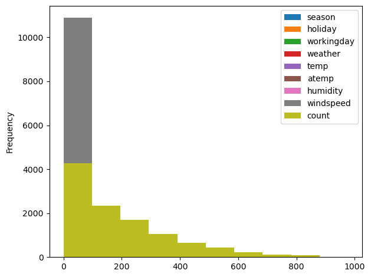

```python
# Create a histogram of all features to show the distribution of each one relative to the data. This is part of the exploritory data analysis
train.plot(kind='hist')
plt.tight_layout()
plt.savefig('OgHistogram.png')
```

```python
# create a new feature
# The year feature doesnt make much difference or even interest us lol
# train['year'] = train['datetime'].dt.year
train['month'] = train['datetime'].dt.month
train['hour'] = train['datetime'].dt.hour
# test['year'] = test['datetime'].dt.year
test['month'] = test['datetime'].dt.month
test['hour'] = test['datetime'].dt.hour
```

```python
test.head()
```

|  | datetime | season | holiday | workingday | weather | temp | atemp | humidity | windspeed | month | hour |
| --- | --- | --- | --- | --- | --- | --- | --- | --- | --- | --- | --- |
| 0 | 2011-01-20 00:00:00 | 1 | 0 | 1 | 1 | 10.66 | 11.365 | 56 | 26.0027 | 1 | 0 |
| 1 | 2011-01-20 01:00:00 | 1 | 0 | 1 | 1 | 10.66 | 13.635 | 56 | 0.0000 | 1 | 1 |
| 2 | 2011-01-20 02:00:00 | 1 | 0 | 1 | 1 | 10.66 | 13.635 | 56 | 0.0000 | 1 | 2 |
| 3 | 2011-01-20 03:00:00 | 1 | 0 | 1 | 1 | 10.66 | 12.880 | 56 | 11.0014 | 1 | 3 |
| 4 | 2011-01-20 04:00:00 | 1 | 0 | 1 | 1 | 10.66 | 12.880 | 56 | 11.0014 | 1 | 4 |

```python
train.head()
```

|  | datetime | season | holiday | workingday | weather | temp | atemp | humidity | windspeed | count | month | hour |
| --- | --- | --- | --- | --- | --- | --- | --- | --- | --- | --- | --- | --- |
| 0 | 2011-01-01 00:00:00 | 1 | 0 | 0 | 1 | 9.84 | 14.395 | 81 | 0.0 | 16 | 1 | 0 |
| 1 | 2011-01-01 01:00:00 | 1 | 0 | 0 | 1 | 9.02 | 13.635 | 80 | 0.0 | 40 | 1 | 1 |
| 2 | 2011-01-01 02:00:00 | 1 | 0 | 0 | 1 | 9.02 | 13.635 | 80 | 0.0 | 32 | 1 | 2 |
| 3 | 2011-01-01 03:00:00 | 1 | 0 | 0 | 1 | 9.84 | 14.395 | 75 | 0.0 | 13 | 1 | 3 |
| 4 | 2011-01-01 04:00:00 | 1 | 0 | 0 | 1 | 9.84 | 14.395 | 75 | 0.0 | 1 | 1 | 4 |

## Make category types for these so models know they are not just numbers

- AutoGluon originally sees these as ints, but in reality they are int representations of a category.
- Setting the dtype to category will classify these as categories in AutoGluon.

```python
train["season"] = train["season"].astype('category')
train["weather"] = train["weather"].astype('category')
test["season"] = test["season"].astype('category')
test["weather"] = test["season"].astype('category')
```

```python
test["weather"].dtype
```

```
CategoricalDtype(categories=[1, 2, 3, 4], ordered=False, categories_dtype=int64)
```

```python
# View are new feature
train.head()
```

|  | datetime | season | holiday | workingday | weather | temp | atemp | humidity | windspeed | count | month | hour |
| --- | --- | --- | --- | --- | --- | --- | --- | --- | --- | --- | --- | --- |
| 0 | 2011-01-01 00:00:00 | 1 | 0 | 0 | 1 | 9.84 | 14.395 | 81 | 0.0 | 16 | 1 | 0 |
| 1 | 2011-01-01 01:00:00 | 1 | 0 | 0 | 1 | 9.02 | 13.635 | 80 | 0.0 | 40 | 1 | 1 |
| 2 | 2011-01-01 02:00:00 | 1 | 0 | 0 | 1 | 9.02 | 13.635 | 80 | 0.0 | 32 | 1 | 2 |
| 3 | 2011-01-01 03:00:00 | 1 | 0 | 0 | 1 | 9.84 | 14.395 | 75 | 0.0 | 13 | 1 | 3 |
| 4 | 2011-01-01 04:00:00 | 1 | 0 | 0 | 1 | 9.84 | 14.395 | 75 | 0.0 | 1 | 1 | 4 |

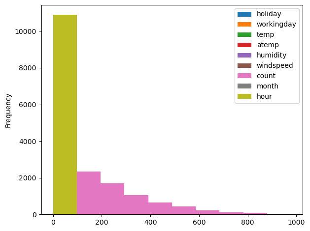

```python
# View histogram of all features again now with the hour feature
train.plot(kind='hist')
plt.tight_layout()
plt.savefig('feature engineered histogram.png')
```

## Step 5: Rerun the model with the same settings as before, just with more features

```python
predictor_new_features = TabularPredictor(label=label, eval_metric=eval_metric).fit(train, time_limit=600,presets='best_quality')
```

[output not shown]

[output cut: 84 more lines]

```
	-31.7718	 = Validation score   (-root_mean_squared_error)
	37.77s	 = Training   runtime
	0.71s	 = Validation runtime
Fitting model: CatBoost_BAG_L2 ... Training model for up to 21.06s of the 20.97s of remaining time.
	Fitting 8 child models (S1F1 - S1F8) | Fitting with ParallelLocalFoldFittingStrategy (2 workers, per: cpus=1, gpus=0, memory=0.83%)
	-31.7545	 = Validation score   (-root_mean_squared_error)
	30.87s	 = Training   runtime
	0.11s	 = Validation runtime
Fitting model: WeightedEnsemble_L3 ... Training model for up to 360.0s of the -16.31s of remaining time.
	Ensemble Weights: {'LightGBM_BAG_L2': 0.6, 'LightGBMXT_BAG_L2': 0.24, 'LightGBMXT_BAG_L1': 0.04, 'CatBoost_BAG_L1': 0.04, 'RandomForestMSE_BAG_L2': 0.04, 'CatBoost_BAG_L2': 0.04}
	-30.3969	 = Validation score   (-root_mean_squared_error)
	0.05s	 = Training   runtime
	0.0s	 = Validation runtime
AutoGluon training complete, total runtime = 442.61s ... Best model: "WeightedEnsemble_L3"
TabularPredictor saved. To load, use: predictor = TabularPredictor.load("AutogluonModels/ag-20240507_085332")
```

```python
predictor_new_features.fit_summary()
```

```
*** Summary of fit() ***
Estimated performance of each model:
                     model   score_val              eval_metric  pred_time_val    fit_time  pred_time_val_marginal  fit_time_marginal  stack_level  can_infer  fit_order
0      WeightedEnsemble_L3  -30.396920  root_mean_squared_error      30.861493  398.711247                0.000620           0.048311            3       True         12
1          LightGBM_BAG_L2  -30.626660  root_mean_squared_error      28.502699  297.189474                0.492584          34.885877            2       True          9
2        LightGBMXT_BAG_L2  -31.236208  root_mean_squared_error      29.550605  295.138538                1.540490          32.834941            2       True          8
3          CatBoost_BAG_L2  -31.754464  root_mean_squared_error      28.115809  293.173233                0.105694          30.869636            2       True         11
4   RandomForestMSE_BAG_L2  -31.771752  root_mean_squared_error      28.722106  300.072483                0.711991          37.768886            2       True         10
5      WeightedEnsemble_L2  -32.323524  root_mean_squared_error      27.951555  262.306449                0.001189           0.051462            2       True          7
6          LightGBM_BAG_L1  -33.917164  root_mean_squared_error       3.912879   53.460019                3.912879          53.460019            1       True          4
7        LightGBMXT_BAG_L1  -34.364334  root_mean_squared_error      23.217782  112.306944               23.217782         112.306944            1       True          3
8          CatBoost_BAG_L1  -36.536768  root_mean_squared_error       0.086282   76.137291                0.086282          76.137291            1       True          6
9   RandomForestMSE_BAG_L1  -38.448701  root_mean_squared_error       0.677143   20.302982                0.677143          20.302982            1       True          5
10   KNeighborsDist_BAG_L1  -84.125061  root_mean_squared_error       0.056281    0.047750                0.056281           0.047750            1       True          2
11   KNeighborsUnif_BAG_L1 -101.546199  root_mean_squared_error       0.059749    0.048610                0.059749           0.048610            1       True          1
Number of models trained: 12
Types of models trained:
{'WeightedEnsembleModel', 'StackerEnsembleModel_KNN', 'StackerEnsembleModel_CatBoost', 'StackerEnsembleModel_LGB', 'StackerEnsembleModel_RF'}
Bagging used: True  (with 8 folds)
Multi-layer stack-ensembling used: True  (with 3 levels)
Feature Metadata (Processed):
(raw dtype, special dtypes):
('category', [])             : 2 | ['season', 'weather']
('float', [])                : 3 | ['temp', 'atemp', 'windspeed']
('int', [])                  : 3 | ['humidity', 'month', 'hour']
('int', ['bool'])            : 2 | ['holiday', 'workingday']
('int', ['datetime_as_int']) : 4 | ['datetime', 'datetime.year', 'datetime.day', 'datetime.dayofweek']
Plot summary of models saved to file: AutogluonModels/ag-20240507_085332SummaryOfModels.html
*** End of fit() summary ***
```

[output not shown]

[output cut: 101 more lines]

```
 11       0.059749    0.048610                0.059749           0.048610

     stack_level  can_infer  fit_order
 0             3       True         12
 1             2       True          9
 2             2       True          8
 3             2       True         11
 4             2       True         10
 5             2       True          7
 6             1       True          4
 7             1       True          3
 8             1       True          6
 9             1       True          5
 10            1       True          2
 11            1       True          1  }
```

```python
predictions_new_features = predictor_new_features.predict(test)
predictions_new_features.head()
```

```
0    15.803367
1     9.631446
2     8.879997
3     7.462783
4     6.473011
Name: count, dtype: float32
```

```python
# Remember to set all negative values to zero
predictions_new_features[predictions_new_features<0]
```

```
Series([], Name: count, dtype: float32)
```

```python
# Remember to set all negative values to zero
predictions_new_features[predictions_new_features<0] = 0
```

```python
# Same submitting predictions
submission["count"] = predictions_new_features
submission.to_csv("submission_new_features.csv", index=False)
```

```python
!kaggle competitions submit -c bike-sharing-demand -f submission_new_features.csv -m "new features"
```

```
Successfully submitted to Bike Sharing Demand
```

```python
!kaggle competitions submissions -c bike-sharing-demand | tail -n +1 | head -n 6
```

```
fileName                     date                 description            status    publicScore  privateScore
---------------------------  -------------------  ---------------------  --------  -----------  ------------
submission_new_features.csv  2024-04-29 13:30:05  new features           complete  0.65303      0.65303
submission.csv               2024-04-29 13:13:15  second raw submission  complete  1.80343      1.80343
submission_new_features.csv  2024-04-29 10:00:00  new features           complete  0.68721      0.68721
submission.csv               2024-04-29 09:23:46  second raw submission  complete  1.80472      1.80472
```

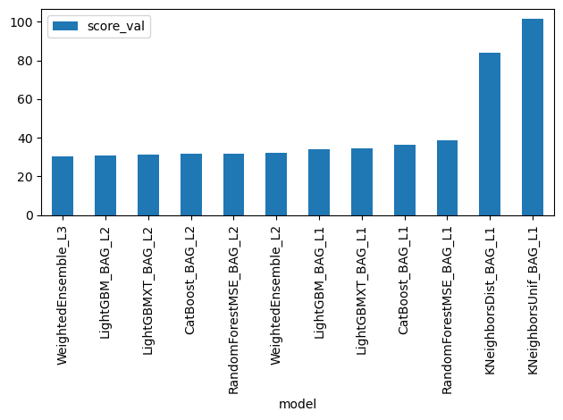

```python
predictor_new_features.leaderboard()
leaderboard = predictor_new_features.leaderboard()#.plot(kind='bar', x='model', y='score_val*-1',)
leaderboard['score_val'] *= -1
leaderboard.plot(kind='bar', x='model', y='score_val').get_figure()
plt.tight_layout()
plt.savefig('new_feature_training_score.png')
```

## Step 6: Hyper parameter optimization

- There are many options for hyper parameter optimization.
- Options are to change the AutoGluon higher level parameters or the individual model hyperparameters.
- The hyperparameters of the models themselves that are in AutoGluon. Those need the `hyperparameter` and `hyperparameter_tune_kwargs` arguments.

```python
from autogluon.common import space

"""
All the variables we will use in our hyper parameter Tuning and the model options along with the HPO kwargs that we use in the
TabulerPredictor .fit() method from autogluon for our predictions on the bike sharing demand preictions.
"""

# Use the root_mean_squared_error as the metric to use for evaluation.
EVAL_METRIC = 'root_mean_squared_error'

HYPERPARAMETER_TUNE_KWARGS = {'num_trials': 5, # 5 to 20
                              'searcher':'auto', # auto to fifo
                              'scheduler':'local', # local to random
                              'verbosity':2,
                             }

save_path = 'HPOAutoGluonModel/'
label='count'
ignored_columns = ['casual','registered']

GBM_OPTIONS = [
    {
        'extra_trees': True,
        'num_boost_round':space.Int(100,200),
        'ag_args': {'name_suffix': 'XT'},
        'boosting':'rf'},  # specifying GBM with XT suffix eg GBMXT
         {},  # default model
        'GBMLarge' #another GBM model
]

RF_OPTIONS = {
    'n_estimators': space.Int(100, 200),
    'max_depth': space.Int(1, 50),
    'random_state': space.Int(0, 100),
    'ag_args': {'name_suffix': 'MSE', 'problem_types': 'regression'}
}

CAT_OPTIONS = {
    'ag_args': {'name_suffix': '_r177', 'priority': -1},
     'depth': space.Int(6,10),
     'learning_rate': 1e-1
}

XGB_OPTIONS = {
    'learning_rate': space.Real(1e-2, 1e-1),
    'ag_args': {'name_suffix': '_r33', 'priority': -8}
}

hyperparameters = {
    'GBM': GBM_OPTIONS,
    'RF': RF_OPTIONS,
    'XGB': XGB_OPTIONS,
    'CAT':CAT_OPTIONS
}
```

```python
predictor_new_hpo = TabularPredictor(
    label=label,
    eval_metric=EVAL_METRIC,
    learner_kwargs={'ignored_columns': ignored_columns},
    path=save_path
).fit(
    train_data=train,
    time_limit=600,
    presets='best_quality',
    hyperparameters=hyperparameters,
    num_bag_folds=6,
    hyperparameter_tune_kwargs=HYPERPARAMETER_TUNE_KWARGS
)
```

[output not shown]

[output cut: 23 more lines]

```
	Train Data (Processed) Memory Usage: 0.79 MB (0.1% of available memory)
Data preprocessing and feature engineering runtime = 0.64s ...
AutoGluon will gauge predictive performance using evaluation metric: 'root_mean_squared_error'
	This metric's sign has been flipped to adhere to being higher_is_better. The metric score can be multiplied by -1 to get the metric value.
	To change this, specify the eval_metric parameter of Predictor()
User-specified model hyperparameters to be fit:
{
	'GBM': [{'extra_trees': True, 'num_boost_round': Int: lower=100, upper=200, 'ag_args': {'name_suffix': 'XT'}}, {}, 'GBMLarge'],
	'RF': {'n_estimators': Int: lower=100, upper=200, 'max_depth': Int: lower=1, upper=50, 'random_state': Int: lower=0, upper=100, 'ag_args': {'name_suffix': 'MSE', 'problem_types': 'regression'}},
	'XGB': {'learning_rate': Real: lower=0.01, upper=0.1, 'ag_args': {'name_suffix': '_r33', 'priority': -8}},
	'CAT': {'ag_args': {'name_suffix': '_r177', 'priority': -1}, 'depth': Int: lower=6, upper=10, 'learning_rate': 0.1},
}
AutoGluon will fit 2 stack levels (L1 to L2) ...
Fitting 6 L1 models ...
Hyperparameter tuning model: LightGBMXT_BAG_L1 ... Tuning model for up to 7.43s of the 74.36s of remaining time.
```

```
	Fitting 6 child models (S1F1 - S1F6) | Fitting with ParallelLocalFoldFittingStrategy (2 workers, per: cpus=1, gpus=0, memory=0.73%)
	Stopping HPO to satisfy time limit...
Fitted model: LightGBMXT_BAG_L1/T1 ...
	-75.7203	 = Validation score   (-root_mean_squared_error)
	23.11s	 = Training   runtime
	0.0s	 = Validation runtime
Hyperparameter tuning model: LightGBM_BAG_L1 ... Tuning model for up to 7.43s of the 50.98s of remaining time.
```

```
	Fitting 6 child models (S1F1 - S1F6) | Fitting with ParallelLocalFoldFittingStrategy (2 workers, per: cpus=1, gpus=0, memory=0.58%)
	Stopping HPO to satisfy time limit...
Fitted model: LightGBM_BAG_L1/T1 ...
	-34.4565	 = Validation score   (-root_mean_squared_error)
	26.07s	 = Training   runtime
	0.0s	 = Validation runtime
Hyperparameter tuning model: RandomForestMSE_BAG_L1 ... Tuning model for up to 7.43s of the 24.7s of remaining time.
```

```
	Stopping HPO to satisfy time limit...
Fitted model: RandomForestMSE_BAG_L1/T1 ...
	-150.2413	 = Validation score   (-root_mean_squared_error)
	0.95s	 = Training   runtime
	0.0s	 = Validation runtime
Fitted model: RandomForestMSE_BAG_L1/T2 ...
	-38.6266	 = Validation score   (-root_mean_squared_error)
	11.79s	 = Training   runtime
	0.0s	 = Validation runtime
Fitting model: LightGBMLarge_BAG_L1 ... Training model for up to 7.43s of the 11.76s of remaining time.
	Fitting 6 child models (S1F1 - S1F6) | Fitting with ParallelLocalFoldFittingStrategy (2 workers, per: cpus=1, gpus=0, memory=0.94%)
	-34.7553	 = Validation score   (-root_mean_squared_error)
	22.77s	 = Training   runtime
	0.44s	 = Validation runtime
Hyperparameter tuning model: CatBoost_r177_BAG_L1 ... Tuning model for up to 7.43s of the -15.58s of remaining time.
```

```
	Fitting 6 child models (S1F1 - S1F6) | Fitting with ParallelLocalFoldFittingStrategy (2 workers, per: cpus=1, gpus=0, memory=0.80%)
	Stopping HPO to satisfy time limit...
Fitted model: CatBoost_r177_BAG_L1/T1 ...
	-54.0825	 = Validation score   (-root_mean_squared_error)
	19.66s	 = Training   runtime
	0.0s	 = Validation runtime
Hyperparameter tuning model: XGBoost_r33_BAG_L1 ... Tuning model for up to 7.43s of the -35.48s of remaining time.
```

```
	Fitting 6 child models (S1F1 - S1F6) | Fitting with ParallelLocalFoldFittingStrategy (2 workers, per: cpus=1, gpus=0, memory=0.91%)
	Stopping HPO to satisfy time limit...
Fitted model: XGBoost_r33_BAG_L1/T1 ...
	-77.6211	 = Validation score   (-root_mean_squared_error)
	19.81s	 = Training   runtime
	0.0s	 = Validation runtime
Fitting model: WeightedEnsemble_L2 ... Training model for up to 74.36s of the -55.52s of remaining time.
	Ensemble Weights: {'LightGBM_BAG_L1/T1': 0.522, 'LightGBMLarge_BAG_L1': 0.391, 'RandomForestMSE_BAG_L1/T2': 0.087}
	-33.599	 = Validation score   (-root_mean_squared_error)
	0.08s	 = Training   runtime
	0.0s	 = Validation runtime
Fitting 6 L2 models ...
Fitting model: WeightedEnsemble_L3 ... Training model for up to 74.36s of the -55.77s of remaining time.
	Ensemble Weights: {'LightGBM_BAG_L1/T1': 0.522, 'LightGBMLarge_BAG_L1': 0.391, 'RandomForestMSE_BAG_L1/T2': 0.087}
	-33.599	 = Validation score   (-root_mean_squared_error)
	0.05s	 = Training   runtime
	0.0s	 = Validation runtime
AutoGluon training complete, total runtime = 131.02s ... Best model: "WeightedEnsemble_L2"
TabularPredictor saved. To load, use: predictor = TabularPredictor.load("HPOAutoGluonModel/")
```

```python
predictor_new_hpo.fit_summary()
```

```
*** Summary of fit() ***
Estimated performance of each model:
                       model  score_val              eval_metric  pred_time_val  fit_time  pred_time_val_marginal  fit_time_marginal  stack_level  can_infer  fit_order
0        WeightedEnsemble_L3  -33.59898  root_mean_squared_error        0.43757  60.68057                 0.00100            0.04745            3       True          9
1        WeightedEnsemble_L2  -33.59898  root_mean_squared_error        0.43823  60.71733                 0.00165            0.08421            2       True          8
2         LightGBM_BAG_L1/T1  -34.45648  root_mean_squared_error        0.00015  26.07148                 0.00015           26.07148            1       True          2
3       LightGBMLarge_BAG_L1  -34.75530  root_mean_squared_error        0.43583  22.77045                 0.43583           22.77045            1       True          5
4  RandomForestMSE_BAG_L1/T2  -38.62665  root_mean_squared_error        0.00060  11.79119                 0.00060           11.79119            1       True          4
5    CatBoost_r177_BAG_L1/T1  -54.08254  root_mean_squared_error        0.00019  19.66425                 0.00019           19.66425            1       True          6
6       LightGBMXT_BAG_L1/T1  -75.72035  root_mean_squared_error        0.00016  23.10837                 0.00016           23.10837            1       True          1
7      XGBoost_r33_BAG_L1/T1  -77.62107  root_mean_squared_error        0.00016  19.80715                 0.00016           19.80715            1       True          7
8  RandomForestMSE_BAG_L1/T1 -150.24131  root_mean_squared_error        0.00020   0.95049                 0.00020            0.95049            1       True          3
Number of models trained: 9
Types of models trained:
{'WeightedEnsembleModel', 'StackerEnsembleModel_XGBoost', 'StackerEnsembleModel_CatBoost', 'StackerEnsembleModel_LGB', 'StackerEnsembleModel_RF'}
Bagging used: True  (with 6 folds)
Multi-layer stack-ensembling used: True  (with 3 levels)
Feature Metadata (Processed):
(raw dtype, special dtypes):
('category', [])             : 2 | ['season', 'weather']
('float', [])                : 3 | ['temp', 'atemp', 'windspeed']
('int', [])                  : 3 | ['humidity', 'month', 'hour']
('int', ['bool'])            : 2 | ['holiday', 'workingday']
('int', ['datetime_as_int']) : 4 | ['datetime', 'datetime.year', 'datetime.day', 'datetime.dayofweek']
Plot summary of models saved to file: HPOAutoGluonModel/SummaryOfModels.html
*** End of fit() summary ***
```

[output not shown]

[output cut: 63 more lines]

```
 5        0.00019  19.66425                 0.00019           19.66425
 6        0.00016  23.10837                 0.00016           23.10837
 7        0.00016  19.80715                 0.00016           19.80715
 8        0.00020   0.95049                 0.00020            0.95049

    stack_level  can_infer  fit_order
 0            3       True          9
 1            2       True          8
 2            1       True          2
 3            1       True          5
 4            1       True          4
 5            1       True          6
 6            1       True          1
 7            1       True          7
 8            1       True          3  }
```

```python
predictions_new_hpo = predictor_new_hpo.predict(test)
predictions_new_hpo.head()
```

```
0    14.687855
1     2.332687
2    -0.634811
3     1.739925
4     1.696112
Name: count, dtype: float32
```

```python
predictions_new_hpo.describe()
```

```
count    6493.000000
mean      185.920090
std       164.730316
min        -6.711980
25%        49.400314
50%       150.787811
75%       271.311798
max       881.343994
Name: count, dtype: float64
```

```python
# Remember to set all negative values to zero
predictions_new_hpo[predictions_new_hpo<0] = 0
```

```python
predictions_new_hpo[predictions_new_hpo<0]
```

```
Series([], Name: count, dtype: float32)
```

```python
predictions_new_hpo
```

```
0        14.687855
1         2.332687
2         0.000000
3         1.739925
4         1.696112
           ...
6488    353.505280
6489    234.061920
6490    160.808990
6491    107.037552
6492     59.917274
Name: count, Length: 6493, dtype: float32
```

```python
# Same submitting predictions
submission["count"] = predictions_new_hpo
submission.to_csv("submission_new_hpo.csv", index=False)
```

```python
!kaggle competitions submit -c bike-sharing-demand -f submission_new_hpo.csv -m "new features with hyperparameters3"
```

```
Successfully submitted to Bike Sharing Demand
```

```python
!kaggle competitions submissions -c bike-sharing-demand | tail -n +1 | head -n 6
```

```
fileName                     date                 description                         status    publicScore  privateScore
---------------------------  -------------------  ----------------------------------  --------  -----------  ------------
submission_new_hpo.csv       2024-05-07 10:43:32  new features with hyperparameters3  complete  0.54303      0.54303
submission_new_hpo.csv       2024-05-07 10:39:03  new features with hyperparameters3  complete  4.76188      4.76188
submission_new_hpo.csv       2024-05-07 10:38:46  new features with hyperparameters   complete  4.76188      4.76188
submission_new_hpo.csv       2024-05-06 20:50:53  new features with hyperparameters   complete  4.76188      4.76188
```

New Score of `0.54303`

## Step 7: Write a Report

### Refer to the markdown file for the full report

### Creating plots and table for report

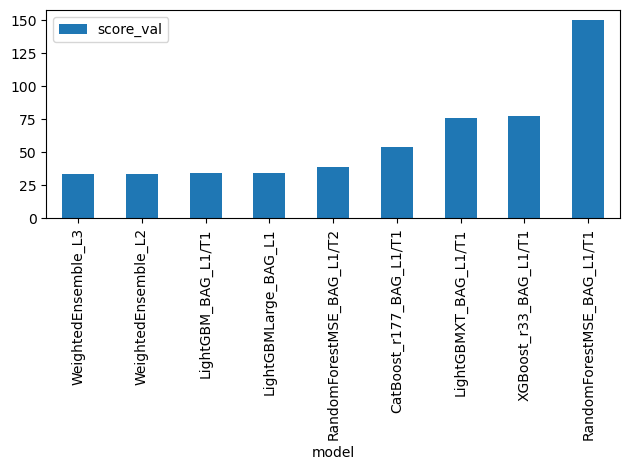

```python
import matplotlib.pyplot as plt
leaderboard = predictor_new_hpo.leaderboard()#.plot(kind='bar', x='model', y='score_val*-1',)
leaderboard['score_val'] *= -1
leaderboard.plot(kind='bar', x='model', y='score_val').get_figure()
plt.tight_layout()
plt.savefig('model_hpo_training_score.png')
```

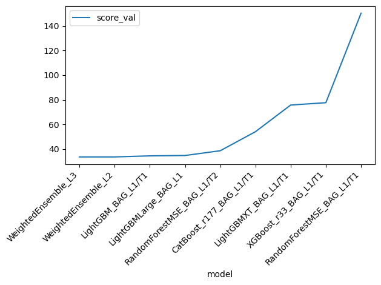

```python
import matplotlib.pyplot as plt
leaderboard = predictor_new_hpo.leaderboard()#.plot(kind='bar', x='model', y='score_val*-1',)
leaderboard['score_val'] *= -1
leaderboard.plot(kind='line', x='model', y='score_val').get_figure()
plt.xticks(rotation=45, ha='right')
plt.tight_layout()
plt.savefig('inverted_model_training_score.png')
```

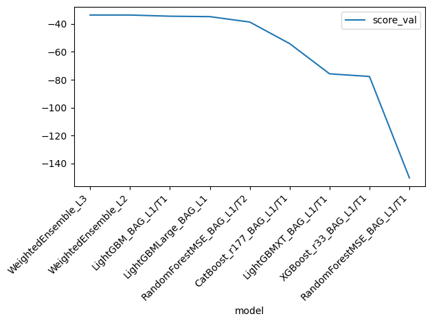

```python
import matplotlib.pyplot as plt
leaderboard = predictor_new_hpo.leaderboard()#.plot(kind='bar', x='model', y='score_val*-1',)
leaderboard.plot(kind='line', x='model', y='score_val').get_figure()
plt.xticks(rotation=45, ha='right')
plt.tight_layout()
plt.savefig('model_training_score.png')
```

# Take the 3 kaggle scores and creating a line plot to show improvement

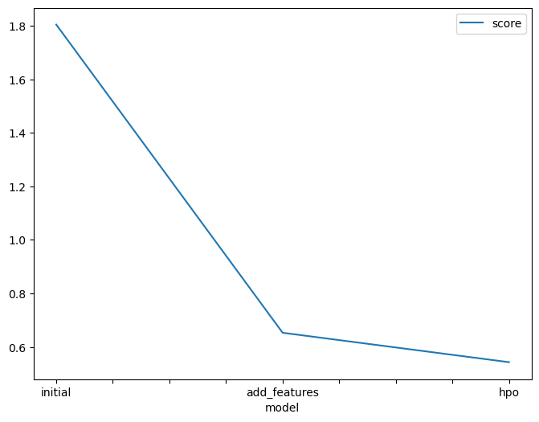

```python
# Taking the top model score from each training run and creating a line plot to show improvement
# You can create these in the notebook and save them to PNG or use some other tool (e.g. google sheets, excel)
fig = pd.DataFrame(
    {
        "model": ["initial", "add_features", "hpo"],
        "score": [1.80472, 0.65303, 0.54303]
    }
).plot(x="model", y="score", figsize=(8, 6)).get_figure()
fig.savefig('model_train_score.png')
```

### Hyperparameter table

```python
# The 3 hyperparameters we tuned with the kaggle score as the result
df = pd.DataFrame( {
    "model": ["initial", "add_features", "hpo"],
    "hpo1": ["default", "default", "GBM:{'extra_trees': True, 'num_boost_round':space.Int(100,200), 'ag_args': {'name_suffix': 'XT'}, 'boosting':'rf'}, {}, 'GBMLarge'"],
    "hpo2": ["default", "default", "RF: {'n_estimators': space.Int(100, 200), 'max_depth': space.Int(1, 50), 'random_state': space.Int(0, 100), 'ag_args': {'name_suffix': 'MSE', 'problem_types': 'regression'}}"],
    "hpo3": ["default", "default", "CAT: {'ag_args': {'name_suffix': '_r177', 'priority': -1}, 'depth': space.Int(6,10), 'learning_rate': 1e-1}"],
    "hpo4": ["default", "default", "XGB:{'learning_rate': space.Real(1e-2, 1e-1), 'ag_args': {'name_suffix': '_r33', 'priority': -8}}"],
    "score": [1.80472, 0.65303, 0.54303]
})
pd.set_option('display.max_colwidth', None) # to view the column values well
df
```

|  | model | hpo1 | hpo2 | hpo3 | hpo4 | score |
| --- | --- | --- | --- | --- | --- | --- |
| 0 | initial | default | default | default | default | 1.80472 |
| 1 | add_features | default | default | default | default | 0.65303 |
| 2 | hpo | GBM:{'extra_trees': True, 'num_boost_round':space.Int(100,200), 'ag_args': {'name_suffix': 'XT'}, 'boosting':'rf'}, {}, 'GBMLarge' | RF: {'n_estimators': space.Int(100, 200), 'max_depth': space.Int(1, 50), 'random_state': space.Int(0, 100), 'ag_args': {'name_suffix': 'MSE', 'problem_types': 'regression'}} | CAT: {'ag_args': {'name_suffix': '_r177', 'priority': -1}, 'depth': space.Int(6,10), 'learning_rate': 1e-1} | XGB:{'learning_rate': space.Real(1e-2, 1e-1), 'ag_args': {'name_suffix': '_r33', 'priority': -8}} | 0.54303 |

## Step 8. Standing Out

Suggestions to Make Your Project Stand Out

- Add more than one feature to the dataset and train models to see if it improves Kaggle score!
- The project suggests separating hour from datetime to have additional feature

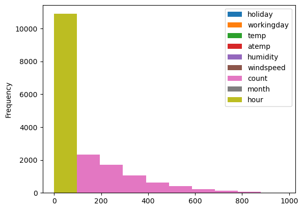

```python
train.plot(kind='hist')
```

```python
test
```

[output not shown]

```python
# Feature that categorizes morning, lunch, and evening rush hour, 7-9am, 11am-1pm, and 5-6pm.
# Categorize rush hours using apply and lambda
train['rush_hour'] = train['hour'].apply(lambda x: 'night' if 0 <= x < 7 else ('morning' if 7 <= x < 11 else ('lunch' if 11 <= x < 17 else 'evening')))
test['rush_hour'] = test['hour'].apply(lambda x: 'night' if 0 <= x < 7 else ('morning' if 7 <= x < 11 else ('lunch' if 11 <= x < 17 else 'evening')))
# Feature that categorizes hot/cold/mild temps from temp.
train['temperature_category'] = train['temp'].apply(lambda x: 'cold' if x <= 15 else ('mild' if x <= 25 else 'hot'))
test['temperature_category'] = test['temp'].apply(lambda x: 'cold' if x <= 15 else ('mild' if x <= 25 else 'hot'))
# Feature that categories very windy/mild wind.
train['wind_category'] = train['windspeed'].apply(lambda x: 'calm' if x <= 10 else ('mild' if x <= 20 else 'very windy'))
test['wind_category'] = test['windspeed'].apply(lambda x: 'calm' if x <= 10 else ('mild' if x <= 20 else 'very windy'))

# Feature that categories very humid/ not humid.
train['humidity_category'] = train['humidity'].apply(lambda x: 'not humid' if x <= 40 else ('mildly humid' if x <= 60 else 'very humid'))
test['humidity_category'] = test['humidity'].apply(lambda x: 'not humid' if x <= 40 else ('mildly humid' if x <= 60 else 'very humid'))
```

```python
# Perform multiple rounds of hyperparameter tuning to see if it improves Kaggle score!
```

1. Test individual algorithm types (KNN, Neural Nets, RF, XGBoost, etc) and write a detailed analysis of which one performs better on this dataset.

```python
from autogluon.common import space

"""
All the variables we will use in our hyper parameter Tuning and the model options along with the HPO kwargs that we use in the
TabulerPredictor .fit() method from autogluon for our predictions on the bike sharing demand preictions.
"""

# Use the root_mean_squared_error as the metric to use for evaluation.
EVAL_METRIC = 'root_mean_squared_error'

HYPERPARAMETER_TUNE_KWARGS = {'num_trials': 5, # 5 to 20
                              'searcher':'auto', # auto to fifo
                              'scheduler':'local', # local to random
                              'verbosity':2,
                             }

save_path = 'HPOAutoGluonModel2/'
label='count'
ignored_columns = ['casual','registered']

GBM_OPTIONS = [{
    'bagging_freq': 5,
    'bagging_fraction': 0.5,
    'feature_fraction':0.25,
    'extra_trees': True,
    'num_boost_round':space.Int(100,200),
    'ag_args': {'name_suffix': 'XT'},
    'boosting':'rf'},  # specifying GBM with XT suffix eg GBMXT
     {},  # default model
    'GBMLarge' #another GBM model
]

RF_OPTIONS = {
    'n_estimators': space.Int(100, 200),
    'max_depth': space.Int(1, 50),
    'random_state': space.Int(0, 100),
    'ag_args': {'name_suffix': 'MSE', 'problem_types': 'regression'}
}

CAT_OPTIONS = {
    'ag_args': {'name_suffix': '_r177', 'priority': -1},
     'depth': space.Int(6,10),
     'learning_rate': 1e-1
}

XGB_OPTIONS = {
    'learning_rate': space.Real(1e-2, 1e-1),
    'ag_args': {'name_suffix': '_r33', 'priority': -8}
}

hyperparameters = {
    'GBM': GBM_OPTIONS,
    'RF': RF_OPTIONS,
    'XGB': XGB_OPTIONS,
    'CAT':CAT_OPTIONS
}
```

```python
predictor_new_hpo = TabularPredictor(
    label=label,
    eval_metric=EVAL_METRIC,
    learner_kwargs={'ignored_columns': ignored_columns},
    path=save_path
).fit(
    train_data=train,
    time_limit=1200,
    presets='best_quality',
    hyperparameters=hyperparameters,
    num_bag_folds=6,
    hyperparameter_tune_kwargs=HYPERPARAMETER_TUNE_KWARGS
)
```

[output not shown]

[output cut: 24 more lines]

[output not shown]

```
	Fitting 6 child models (S1F1 - S1F6) | Fitting with ParallelLocalFoldFittingStrategy (2 workers, per: cpus=1, gpus=0, memory=1.05%)
	Fitting 6 child models (S1F1 - S1F6) | Fitting with ParallelLocalFoldFittingStrategy (2 workers, per: cpus=1, gpus=0, memory=1.33%)
	Fitting 6 child models (S1F1 - S1F6) | Fitting with ParallelLocalFoldFittingStrategy (2 workers, per: cpus=1, gpus=0, memory=0.88%)
	Stopping HPO to satisfy time limit...
Fitted model: LightGBMXT_BAG_L1/T1 ...
	-109.2042	 = Validation score   (-root_mean_squared_error)
	27.17s	 = Training   runtime
	0.0s	 = Validation runtime
Fitted model: LightGBMXT_BAG_L1/T2 ...
	-110.1308	 = Validation score   (-root_mean_squared_error)
	23.5s	 = Training   runtime
	0.0s	 = Validation runtime
Fitted model: LightGBMXT_BAG_L1/T3 ...
	-108.2655	 = Validation score   (-root_mean_squared_error)
	19.03s	 = Training   runtime
	0.0s	 = Validation runtime
Hyperparameter tuning model: LightGBM_BAG_L1 ... Tuning model for up to 78.09s of the 710.77s of remaining time.
```

```
	Fitting 6 child models (S1F1 - S1F6) | Fitting with ParallelLocalFoldFittingStrategy (2 workers, per: cpus=1, gpus=0, memory=0.82%)
	Fitting 6 child models (S1F1 - S1F6) | Fitting with ParallelLocalFoldFittingStrategy (2 workers, per: cpus=1, gpus=0, memory=1.18%)
	Stopping HPO to satisfy time limit...
Fitted model: LightGBM_BAG_L1/T1 ...
	-33.7138	 = Validation score   (-root_mean_squared_error)
	39.81s	 = Training   runtime
	0.0s	 = Validation runtime
Fitted model: LightGBM_BAG_L1/T2 ...
	-33.5345	 = Validation score   (-root_mean_squared_error)
	43.97s	 = Training   runtime
	0.0s	 = Validation runtime
Hyperparameter tuning model: RandomForestMSE_BAG_L1 ... Tuning model for up to 78.09s of the 626.69s of remaining time.
```

```
Fitted model: RandomForestMSE_BAG_L1/T1 ...
	-150.2413	 = Validation score   (-root_mean_squared_error)
	1.27s	 = Training   runtime
	0.0s	 = Validation runtime
Fitted model: RandomForestMSE_BAG_L1/T2 ...
	-38.5424	 = Validation score   (-root_mean_squared_error)
	10.46s	 = Training   runtime
	0.0s	 = Validation runtime
Fitted model: RandomForestMSE_BAG_L1/T3 ...
	-111.7214	 = Validation score   (-root_mean_squared_error)
	3.19s	 = Training   runtime
	0.0s	 = Validation runtime
Fitted model: RandomForestMSE_BAG_L1/T4 ...
	-38.8187	 = Validation score   (-root_mean_squared_error)
	10.4s	 = Training   runtime
	0.0s	 = Validation runtime
Fitted model: RandomForestMSE_BAG_L1/T5 ...
	-38.6411	 = Validation score   (-root_mean_squared_error)
	17.29s	 = Training   runtime
	0.0s	 = Validation runtime
Fitting model: LightGBMLarge_BAG_L1 ... Training model for up to 78.09s of the 583.52s of remaining time.
	Fitting 6 child models (S1F1 - S1F6) | Fitting with ParallelLocalFoldFittingStrategy (2 workers, per: cpus=1, gpus=0, memory=1.34%)
	-33.5276	 = Validation score   (-root_mean_squared_error)
	68.15s	 = Training   runtime
	5.47s	 = Validation runtime
Hyperparameter tuning model: CatBoost_r177_BAG_L1 ... Tuning model for up to 78.09s of the 508.2s of remaining time.
```

```
	Fitting 6 child models (S1F1 - S1F6) | Fitting with ParallelLocalFoldFittingStrategy (2 workers, per: cpus=1, gpus=0, memory=1.00%)
	Stopping HPO to satisfy time limit...
Fitted model: CatBoost_r177_BAG_L1/T1 ...
	-36.6203	 = Validation score   (-root_mean_squared_error)
	76.6s	 = Training   runtime
	0.0s	 = Validation runtime
Hyperparameter tuning model: XGBoost_r33_BAG_L1 ... Tuning model for up to 78.09s of the 431.34s of remaining time.
```

```
	Fitting 6 child models (S1F1 - S1F6) | Fitting with ParallelLocalFoldFittingStrategy (2 workers, per: cpus=1, gpus=0, memory=1.31%)
	Stopping HPO to satisfy time limit...
Fitted model: XGBoost_r33_BAG_L1/T1 ...
	-36.326	 = Validation score   (-root_mean_squared_error)
	79.23s	 = Training   runtime
	0.0s	 = Validation runtime
Fitting model: WeightedEnsemble_L2 ... Training model for up to 360.0s of the 351.76s of remaining time.
	Ensemble Weights: {'LightGBM_BAG_L1/T1': 0.333, 'LightGBMLarge_BAG_L1': 0.292, 'LightGBM_BAG_L1/T2': 0.167, 'CatBoost_r177_BAG_L1/T1': 0.167, 'RandomForestMSE_BAG_L1/T5': 0.042}
	-32.5306	 = Validation score   (-root_mean_squared_error)
	0.09s	 = Training   runtime
	0.0s	 = Validation runtime
Fitting 6 L2 models ...
Hyperparameter tuning model: LightGBMXT_BAG_L2 ... Tuning model for up to 52.73s of the 351.51s of remaining time.
```

```
	Fitting 6 child models (S1F1 - S1F6) | Fitting with ParallelLocalFoldFittingStrategy (2 workers, per: cpus=1, gpus=0, memory=1.41%)
	Fitting 6 child models (S1F1 - S1F6) | Fitting with ParallelLocalFoldFittingStrategy (2 workers, per: cpus=1, gpus=0, memory=2.28%)
	Stopping HPO to satisfy time limit...
Fitted model: LightGBMXT_BAG_L2/T1 ...
	-42.4946	 = Validation score   (-root_mean_squared_error)
	22.88s	 = Training   runtime
	0.0s	 = Validation runtime
Fitted model: LightGBMXT_BAG_L2/T2 ...
	-43.5944	 = Validation score   (-root_mean_squared_error)
	19.98s	 = Training   runtime
	0.0s	 = Validation runtime
Hyperparameter tuning model: LightGBM_BAG_L2 ... Tuning model for up to 52.73s of the 308.28s of remaining time.
```

```
	Fitting 6 child models (S1F1 - S1F6) | Fitting with ParallelLocalFoldFittingStrategy (2 workers, per: cpus=1, gpus=0, memory=1.38%)
	Stopping HPO to satisfy time limit...
Fitted model: LightGBM_BAG_L2/T1 ...
	-33.2415	 = Validation score   (-root_mean_squared_error)
	31.92s	 = Training   runtime
	0.0s	 = Validation runtime
Hyperparameter tuning model: RandomForestMSE_BAG_L2 ... Tuning model for up to 52.73s of the 276.12s of remaining time.
```

```
	Stopping HPO to satisfy time limit...
Fitted model: RandomForestMSE_BAG_L2/T1 ...
	-101.6984	 = Validation score   (-root_mean_squared_error)
	3.27s	 = Training   runtime
	0.0s	 = Validation runtime
Fitted model: RandomForestMSE_BAG_L2/T2 ...
	-33.6205	 = Validation score   (-root_mean_squared_error)
	39.8s	 = Training   runtime
	0.0s	 = Validation runtime
Fitting model: LightGBMLarge_BAG_L2 ... Training model for up to 52.73s of the 232.68s of remaining time.
	Fitting 6 child models (S1F1 - S1F6) | Fitting with ParallelLocalFoldFittingStrategy (2 workers, per: cpus=1, gpus=0, memory=2.27%)
	-33.9795	 = Validation score   (-root_mean_squared_error)
	46.34s	 = Training   runtime
	0.35s	 = Validation runtime
Hyperparameter tuning model: CatBoost_r177_BAG_L2 ... Tuning model for up to 52.73s of the 181.52s of remaining time.
```

```
	Fitting 6 child models (S1F1 - S1F6) | Fitting with ParallelLocalFoldFittingStrategy (2 workers, per: cpus=1, gpus=0, memory=1.97%)
	Stopping HPO to satisfy time limit...
Fitted model: CatBoost_r177_BAG_L2/T1 ...
	-33.0928	 = Validation score   (-root_mean_squared_error)
	55.28s	 = Training   runtime
	0.0s	 = Validation runtime
Hyperparameter tuning model: XGBoost_r33_BAG_L2 ... Tuning model for up to 52.73s of the 125.92s of remaining time.
```

```
	Fitting 6 child models (S1F1 - S1F6) | Fitting with ParallelLocalFoldFittingStrategy (2 workers, per: cpus=1, gpus=0, memory=2.19%)
	Stopping HPO to satisfy time limit...
Fitted model: XGBoost_r33_BAG_L2/T1 ...
	-33.2831	 = Validation score   (-root_mean_squared_error)
	53.69s	 = Training   runtime
	0.0s	 = Validation runtime
Fitting model: WeightedEnsemble_L3 ... Training model for up to 360.0s of the 71.86s of remaining time.
	Ensemble Weights: {'LightGBM_BAG_L1/T1': 0.238, 'CatBoost_r177_BAG_L2/T1': 0.238, 'LightGBMLarge_BAG_L1': 0.19, 'LightGBM_BAG_L1/T2': 0.095, 'CatBoost_r177_BAG_L1/T1': 0.095, 'XGBoost_r33_BAG_L2/T1': 0.095, 'RandomForestMSE_BAG_L2/T2': 0.048}
	-32.4365	 = Validation score   (-root_mean_squared_error)
	0.11s	 = Training   runtime
	0.0s	 = Validation runtime
AutoGluon training complete, total runtime = 710.52s ... Best model: "WeightedEnsemble_L3"
TabularPredictor saved. To load, use: predictor = TabularPredictor.load("HPOAutoGluonModel2/")
```

```python
predictor_new_hpo2.fit_summary()
```

[output not shown]

[output not shown]

[output cut: 250 more lines]

[output not shown]

```python
predictions_new_hpo2 = predictor_new_hpo2.predict(test)
predictions_new_hpo2.head()
```

```
0    14.31021
1     2.02067
2     0.15912
3     2.90807
4     2.99283
Name: count, dtype: float32
```

```python
# Remember to set all negative values to zero
predictions_new_hpo2[predictions_new_hpo2<0] = 0
```

```python
# Same submitting predictions
submission["count"] = predictions_new_hpo2
submission.to_csv("submission_new_hpo3.csv", index=False)
```

```python
!kaggle competitions submit -c bike-sharing-demand -f submission_new_hpo.csv -m "new features with hpo 3"
```

```
Successfully submitted to Bike Sharing Demand
```

```python
!kaggle competitions submissions -c bike-sharing-demand | tail -n +1 | head -n 6
```

```
fileName                     date                 description                         status    publicScore  privateScore
---------------------------  -------------------  ----------------------------------  --------  -----------  ------------
submission_new_hpo.csv       2024-05-07 14:37:00  new features with hpo 3             complete  0.54303      0.54303
submission_new_hpo.csv       2024-05-07 13:48:25  new features with hpo 2             complete  0.54303      0.54303
submission_new_hpo.csv       2024-05-07 10:43:32  new features with hyperparameters3  complete  0.54303      0.54303
submission_new_hpo.csv       2024-05-07 10:39:03  new features with hyperparameters3  complete  4.76188      4.76188
```

## Step 9. Reporting

1. Plot model training performance with more than just the top model.
2. Plot correlation matrix of all features. Heatmap or scatter plot.